# Proyecto final

## Modelo 1 - Clasificación

### Programación de Inteligencia Artificial

### Redes neuronales con imágenes

# Juan Antonio Donet

[Github](https://github.com/hechix/Clasificar-y-segmentar-radiografias)

# Contexto

El proyecto consiste en 3 partes:

- 1. Clasificador, (Este notebook) Crear una red neuronal que distinga entre radiografías de pacientes, tomadas de frente o desde el lateral, y clasificarlas según si son frontales o laterales.
- 1. Segmentador, Crear una red neuronal tomando la radiografía frontal, segmente los pulmones.
- 1. Clasificar y segmentar, Crear un pequeño programa que al pasarle una radiografía, haga lo siguiente:
     - 1. Usar Clasificador para clasificar como frontal o lateral, en caso de no ser frontal, dar un error.
     - 1. Usar Segmentador para segmentar los pulmones.

# Estrategia

- 1. Crear un modelo base, y ver su rendimiento.
- 1. Intentar modificar el modelo base para que sea más eficiente y tenga menos tasa de falsos positivos / negativos.
- 1. Seleccionar el modelo que mejor se adapte a los datos.

# 0. Importes, carga y preparación de datos

```python
import tensorflow as tf
import cv2
import numpy as np
import os
import matplotlib.pyplot as plt
import random as rnd
import json
from sklearn.metrics import confusion_matrix
import pandas as pd
```

```python
IMG_LADO = 128
```

Carga la imágen en escala de grises de 0 a 1, con tamaño IMG_LADO x IMG_LADO.

```python
def cargar_img(ruta):
    img = cv2.imread(ruta)
    img = cv2.cvtColor(img, cv2.COLOR_BGR2GRAY)
    img = cv2.resize(img, (IMG_LADO, IMG_LADO))
    img = img.astype(np.float32)
    img = img / 255.0
    return img
```

Genera 2 listas:

- imgs: las imágenes procesadas por cargar_imágen, cada imagen se copia y se inserta volteada sobre el eje x, teniendo 2 imágenes por cada imagen original.
- etiquetas: las etiquetas de cada imagen, definidas como 0 o 1.

Genera etiquetas_nombres, que un diccionario definiendo los nombres de las etiquetas. Suele ser: {0: 'frontal', 1: 'lateral'}.

Las dos listas se aleatorizan, sin perder la relacion entre ellas.

```python
def generar_dataset(ruta):
    rnd.seed(10)
    imgs = []
    etiquetas = []
    etiquetas_nombres = {}
    for etiqueta, directorio in enumerate(os.listdir(ruta)):
        etiquetas_nombres[etiqueta] = directorio
        for archivo in os.listdir(ruta + directorio):
            img = cargar_img(ruta + directorio + '/' + archivo)
            volteado_horizontal = np.flip(img, 1)
            imgs.append(img)
            imgs.append(volteado_horizontal)
            etiquetas.append(etiqueta)
            etiquetas.append(etiqueta)

    for i in range(len(imgs)):
        n = rnd.randint(i, len(imgs) - 1)
        imgs[n], imgs[i] = imgs[i], imgs[n]
        etiquetas[n], etiquetas[i] = etiquetas[i], etiquetas[n]

    return np.array(imgs), np.array(etiquetas), etiquetas_nombres
```

Generar datasets y comprobar su tamaño, y que hayan los 2 tipos de imágenes en cada uno de ellos.

```python
x_train, y_train, y_train_etiquetas = generar_dataset('frontal_lateral/train/')
x_vali, y_vali, y_vali_etiquetas = generar_dataset('frontal_lateral/validation/')
x_test, y_test, y_test_etiquetas = generar_dataset('frontal_lateral/test/')

pd_y_train = pd.DataFrame(y_train)
pd_y_train.columns = ['etiqueta']
pd_y_train['nombre'] = pd_y_train['etiqueta'].map(y_train_etiquetas)
pd_y_train.drop('etiqueta', axis=1, inplace=True)

pd_y_vali = pd.DataFrame(y_vali)
pd_y_vali.columns = ['etiqueta']
pd_y_vali['nombre'] = pd_y_vali['etiqueta'].map(y_vali_etiquetas)
pd_y_vali.drop('etiqueta', axis=1, inplace=True)

pd_y_test = pd.DataFrame(y_test)
pd_y_test.columns = ['etiqueta']
pd_y_test['nombre'] = pd_y_test['etiqueta'].map(y_test_etiquetas)
pd_y_test.drop('etiqueta', axis=1, inplace=True)

print('y_train', pd_y_train.value_counts(), sep='\n', end='\n\n')
print('y_vali', pd_y_vali.value_counts(), sep='\n', end='\n\n')
print('y_test', pd_y_test.value_counts(), sep='\n', end='\n\n')
```

```
y_train
nombre
frontal    612
lateral    588
dtype: int64

y_vali
nombre
frontal    200
lateral    200
dtype: int64

y_test
nombre
frontal    200
lateral    200
dtype: int64
```

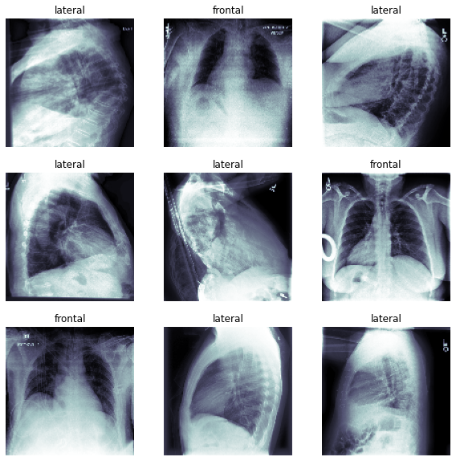

```python
figura = plt.figure(figsize=(10, 10))
for n in range(9):
    hueco = figura.add_subplot(3, 3, n + 1)
    hueco.imshow(x_train[n], cmap='bone')
    hueco.set_title(y_train_etiquetas[y_train[n]])
    hueco.axis('off')
```

# 1. Creación de los modelos

## 1.0. Función para automatizar entrenamiento y visualización de resultados

Si el modelo ya existe en el disco, lo carga.

Si no existe, lo entrena y lo guarda en disco.

Crea el gráfico de pérdidas y validación, con la matriz de confusión de positivos y negativos. Lo hace en función de si la salida es >= 0.5 es positivo o sino, negativo.

```python
def entrenar_y_guardar_modelo(modelo, nombre):
    model_checkpoint_callback = tf.keras.callbacks.ModelCheckpoint(
        filepath=f'modelos/{nombre}.h5',
        monitor='binary_accuracy',
        mode='max',
        save_best_only=True,
        verbose=0)

    modelo.fit(x_train, y_train, epochs=10, validation_data=(x_vali, y_vali), callbacks=[model_checkpoint_callback], verbose= 0)
    historial = modelo.history.history
    evaluacion = modelo.evaluate(x_test, y_test, verbose=0)

    guardar_modelo(historial, evaluacion, nombre)

    return modelo, historial, evaluacion

def guardar_modelo(historial, evaluacion, nombre):
    open('modelos/' + nombre + '_historial.json', 'w').write(json.dumps(historial))
    open('modelos/' + nombre + '_evaluacion.json', 'w').write(json.dumps(evaluacion))


def cargar_modelo(modelo, nombre):
    modelo.load_weights('modelos/' + nombre + '.h5')
    historial = json.loads(open('modelos/' + nombre + '_historial.json').read())
    evaluacion = json.loads(open('modelos/' + nombre + '_evaluacion.json').read())

    return modelo, historial, evaluacion

def clasifica_predicciones(predicciones):
    for i in range(len(predicciones)):
        predicciones[i] = 1 if predicciones[i] >= 0.5 else 0

    return predicciones

def dibujar(modelo, historial, evaluacion):
    confusion = confusion_matrix(y_test, clasifica_predicciones(modelo.predict(x_test)))
    figura = plt.figure(figsize=(30,10))
    hueco = figura.add_subplot(1,3,1)
    hueco.plot(historial['loss'], 'b--',label='Entrenamiento')
    hueco.plot(historial['val_loss'], 'g-', label='Validación')
    hueco.plot(list(range(len(historial['loss']))), [evaluacion[0] for _ in historial['loss']], 'r-', label='Evaluación')
    hueco.set_title(f'Pérdida {evaluacion[0]:.4f}')
    hueco.set_ylabel('Perdida')
    hueco.set_xlabel('Epocas')
    hueco.legend()

    hueco = figura.add_subplot(1,3,2)
    hueco.plot(historial['binary_accuracy'], 'b--', label='Entrenamiento')
    hueco.plot(historial['val_binary_accuracy'],'g-', label='Validación')
    hueco.plot(list(range(len(historial['binary_accuracy']))), [evaluacion[1] for _ in historial['binary_accuracy']], 'r-', label='Evaluación')
    hueco.set_title(f'Precisión {evaluacion[1]:.4f}')
    hueco.set_ylabel('Precisión')
    hueco.set_xlabel('Epocas')
    hueco.legend()

    hueco = figura.add_subplot(1,3,3)
    hueco.imshow(confusion, cmap='summer')
    hueco.set_title('Matriz de Confusión')
    hueco.set_ylabel('Etiquetas Reales')
    hueco.set_xlabel('Etiquetas Predichas')
    hueco.set_xticks(range(len(y_test_etiquetas)))
    hueco.set_yticks(range(len(y_test_etiquetas)))
    hueco.set_xticklabels(y_test_etiquetas.values())
    hueco.set_yticklabels(y_test_etiquetas.values())

    for (j,i),label in np.ndenumerate(confusion):
        hueco.text(i,j,label,ha='center',va='center')
        hueco.text(i,j,label,ha='center',va='center')

def entrenar_y_visualizar(modelo, nombre):
    if os.path.exists('modelos/' + nombre + '.h5'):
        modelo, historial, evaluacion = cargar_modelo(modelo, nombre)
    else:
        modelo, historial, evaluacion = entrenar_y_guardar_modelo(modelo, nombre)

    dibujar(modelo, historial, evaluacion)
```

## 1.1. Modelo 1

El primer modelo, o modelo base, voy a definirlo con 4 secciones convolucionales, de 2 capas cada una seguidas por maxpooling, y un embudo, de 128 neuronas, dividiendo a la mitad de las neuronas de la capa anterior, todas ellas relu, hasta llegar a la salida, la cual será 1 neurona sigmoide.

El optimizador será adam, la perdida binary_crossentropy, y la métrica será precisión binaria.

Uso adam porque es el que generalmente usamos, y las funciones binarias ya que es un problema de clasificación binaria.

```python
entrada = tf.keras.Input(shape=(IMG_LADO, IMG_LADO, 1))

# Extraer caracteristicas
# 128
x = tf.keras.layers.Conv2D(16, (3, 3), activation='relu', padding='same')(entrada)
x = tf.keras.layers.Conv2D(16, (3, 3), activation='relu', padding='same')(x)
x = tf.keras.layers.MaxPooling2D(pool_size=(2, 2))(x)

# 64
x = tf.keras.layers.Conv2D(32, (3, 3), activation='relu', padding='same')(x)
x = tf.keras.layers.Conv2D(32, (3, 3), activation='relu', padding='same')(x)
x = tf.keras.layers.MaxPooling2D(pool_size=(2, 2))(x)

# 32
x = tf.keras.layers.Conv2D(64, (3, 3), activation='relu', padding='same')(x)
x = tf.keras.layers.Conv2D(64, (3, 3), activation='relu', padding='same')(x)
x = tf.keras.layers.MaxPooling2D(pool_size=(2, 2))(x)

# 16
x = tf.keras.layers.Conv2D(128, (3, 3), activation='relu', padding='same')(x)
x = tf.keras.layers.Conv2D(128, (3, 3), activation='relu', padding='same')(x)
x = tf.keras.layers.MaxPooling2D(pool_size=(2, 2))(x)

# Claisificador
x = tf.keras.layers.Flatten()(x)
x = tf.keras.layers.Dense(128, activation='relu')(x)
x = tf.keras.layers.Dense(64, activation='relu')(x)
x = tf.keras.layers.Dense(32, activation='relu')(x)
x = tf.keras.layers.Dense(16, activation='relu')(x)
x = tf.keras.layers.Dense(1, activation='sigmoid')(x)

clasificador_1 = tf.keras.Model(inputs=entrada, outputs=x)
clasificador_1.compile(optimizer = 'adam', loss = 'binary_crossentropy', metrics = ['binary_accuracy'])
```

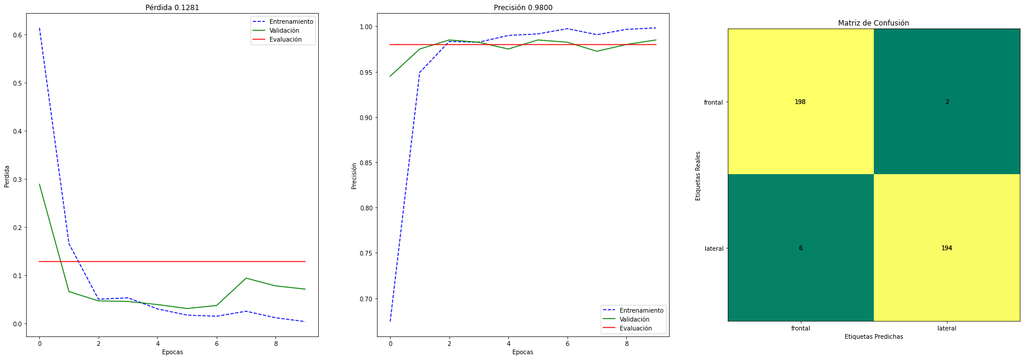

```python
entrenar_y_visualizar(clasificador_1, 'clasificador_1')
```

Me da muy buenos resultados, y no creo que pueda mejorarlos, por lo menos no sin cambiar la arquitectura.

Solo hay 8 registros erróneos, 6 falsos frontales y 2 falsos laterales.

Lo cual implica que el 2% de los registros son erróneos.

## 1.2. Modelo 2

Voy a probar el mismo modelo, pero cambiando la pérdida, a ver si usando una enfocada a regresión mejora el rendimiento.

```python
entrada = tf.keras.Input(shape=(IMG_LADO, IMG_LADO, 1))

# Extraer caracteristicas
# 128
x = tf.keras.layers.Conv2D(16, (3, 3), activation='relu', padding='same')(entrada)
x = tf.keras.layers.Conv2D(16, (3, 3), activation='relu', padding='same')(x)
x = tf.keras.layers.MaxPooling2D(pool_size=(2, 2))(x)

# 64
x = tf.keras.layers.Conv2D(32, (3, 3), activation='relu', padding='same')(x)
x = tf.keras.layers.Conv2D(32, (3, 3), activation='relu', padding='same')(x)
x = tf.keras.layers.MaxPooling2D(pool_size=(2, 2))(x)

# 32
x = tf.keras.layers.Conv2D(64, (3, 3), activation='relu', padding='same')(x)
x = tf.keras.layers.Conv2D(64, (3, 3), activation='relu', padding='same')(x)
x = tf.keras.layers.MaxPooling2D(pool_size=(2, 2))(x)

# 16
x = tf.keras.layers.Conv2D(128, (3, 3), activation='relu', padding='same')(x)
x = tf.keras.layers.Conv2D(128, (3, 3), activation='relu', padding='same')(x)
x = tf.keras.layers.MaxPooling2D(pool_size=(2, 2))(x)

# Claisificador
x = tf.keras.layers.Flatten()(x)
x = tf.keras.layers.Dense(128, activation='relu')(x)
x = tf.keras.layers.Dense(64, activation='relu')(x)
x = tf.keras.layers.Dense(32, activation='relu')(x)
x = tf.keras.layers.Dense(16, activation='relu')(x)
x = tf.keras.layers.Dense(1, activation='sigmoid')(x)

clasificador_2 = tf.keras.Model(inputs=entrada, outputs=x)
clasificador_2.compile(optimizer = 'adam', loss = 'mse', metrics = ['binary_accuracy'])
```

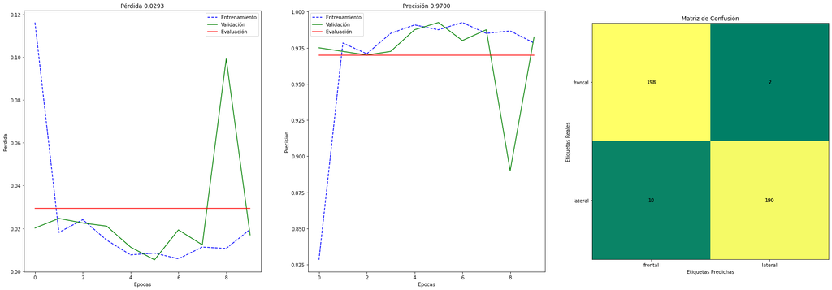

```python
entrenar_y_visualizar(clasificador_2, 'clasificador_2')
```

El resultado es peor en los falsos frontales, y además ha dado un sobreajuste raro en la epoca 8 de validación.

El 3% de los resultados son erróneos.

## 1.3. Modelo 3

Voy a probar esta vez a cambiar adam por rmsprop, que en otras prácticas me ha dado buenos resultados.

```python
entrada = tf.keras.Input(shape=(IMG_LADO, IMG_LADO, 1))

# Extraer caracteristicas
# 128
x = tf.keras.layers.Conv2D(16, (3, 3), activation='relu', padding='same')(entrada)
x = tf.keras.layers.Conv2D(16, (3, 3), activation='relu', padding='same')(x)
x = tf.keras.layers.MaxPooling2D(pool_size=(2, 2))(x)

# 64
x = tf.keras.layers.Conv2D(32, (3, 3), activation='relu', padding='same')(x)
x = tf.keras.layers.Conv2D(32, (3, 3), activation='relu', padding='same')(x)
x = tf.keras.layers.MaxPooling2D(pool_size=(2, 2))(x)

# 32
x = tf.keras.layers.Conv2D(64, (3, 3), activation='relu', padding='same')(x)
x = tf.keras.layers.Conv2D(64, (3, 3), activation='relu', padding='same')(x)
x = tf.keras.layers.MaxPooling2D(pool_size=(2, 2))(x)

# 16
x = tf.keras.layers.Conv2D(128, (3, 3), activation='relu', padding='same')(x)
x = tf.keras.layers.Conv2D(128, (3, 3), activation='relu', padding='same')(x)
x = tf.keras.layers.MaxPooling2D(pool_size=(2, 2))(x)

# Claisificador
x = tf.keras.layers.Flatten()(x)
x = tf.keras.layers.Dense(128, activation='relu')(x)
x = tf.keras.layers.Dense(64, activation='relu')(x)
x = tf.keras.layers.Dense(32, activation='relu')(x)
x = tf.keras.layers.Dense(16, activation='relu')(x)
x = tf.keras.layers.Dense(1, activation='sigmoid')(x)

clasificador_3 = tf.keras.Model(inputs=entrada, outputs=x)
clasificador_3.compile(optimizer = 'rmsprop', loss = 'binary_crossentropy', metrics = ['binary_accuracy'])
```

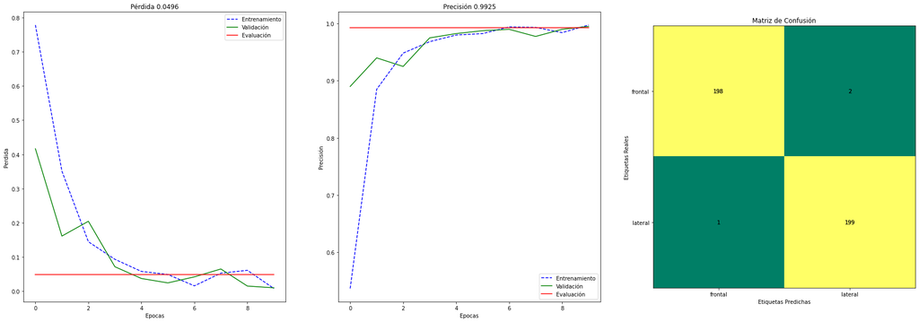

```python
entrenar_y_visualizar(clasificador_3, 'clasificador_3')
```

Este optimizador da mejores resultados, sólo el 0.75% de los registros son erróneos.

## 1.4. Modelo 4

El modelo 4 va a ser un fine-tunning del modelo 3, voy a usar los datos de validacion en train y viceversa... porque puedo.

```python
entrada = tf.keras.Input(shape=(IMG_LADO, IMG_LADO, 1))

# Extraer caracteristicas
# 128
x = tf.keras.layers.Conv2D(16, (3, 3), activation='relu', padding='same')(entrada)
x = tf.keras.layers.Conv2D(16, (3, 3), activation='relu', padding='same')(x)
x = tf.keras.layers.MaxPooling2D(pool_size=(2, 2))(x)

# 64
x = tf.keras.layers.Conv2D(32, (3, 3), activation='relu', padding='same')(x)
x = tf.keras.layers.Conv2D(32, (3, 3), activation='relu', padding='same')(x)
x = tf.keras.layers.MaxPooling2D(pool_size=(2, 2))(x)

# 32
x = tf.keras.layers.Conv2D(64, (3, 3), activation='relu', padding='same')(x)
x = tf.keras.layers.Conv2D(64, (3, 3), activation='relu', padding='same')(x)
x = tf.keras.layers.MaxPooling2D(pool_size=(2, 2))(x)

# 16
x = tf.keras.layers.Conv2D(128, (3, 3), activation='relu', padding='same')(x)
x = tf.keras.layers.Conv2D(128, (3, 3), activation='relu', padding='same')(x)
x = tf.keras.layers.MaxPooling2D(pool_size=(2, 2))(x)

# Claisificador
x = tf.keras.layers.Flatten()(x)
x = tf.keras.layers.Dense(128, activation='relu')(x)
x = tf.keras.layers.Dense(64, activation='relu')(x)
x = tf.keras.layers.Dense(32, activation='relu')(x)
x = tf.keras.layers.Dense(16, activation='relu')(x)
x = tf.keras.layers.Dense(1, activation='sigmoid')(x)

clasificador_4 = tf.keras.Model(inputs=entrada, outputs=x)

clasificador_4, historial_4, _ = cargar_modelo(clasificador_4, 'clasificador_3')

model_checkpoint_callback = tf.keras.callbacks.ModelCheckpoint(
    filepath=f'modelos/clasificador_4.h5',
    monitor='binary_accuracy',
    mode='max',
    save_best_only=True,
    verbose=0)

clasificador_4.compile(optimizer = tf.keras.optimizers.RMSprop(learning_rate=0.0001), loss = 'binary_crossentropy', metrics = ['binary_accuracy'])
```

Para que no me lo entrene cada vez que ejecuto el notebook

```python
if not os.path.exists('modelos/clasificador_4.h5'):
    clasificador_4.fit(x_vali, y_vali, epochs=10, validation_data=(x_train, y_train), callbacks=[model_checkpoint_callback], verbose= 0)
    historial_4['loss'] += clasificador_4.history.history['loss']
    historial_4['binary_accuracy'] += clasificador_4.history.history['binary_accuracy']
    historial_4['val_loss'] += clasificador_4.history.history['val_loss']
    historial_4['val_binary_accuracy'] += clasificador_4.history.history['val_binary_accuracy']

    evaluacion_4 = clasificador_4.evaluate(x_test, y_test, verbose=0)

    guardar_modelo(historial_4, evaluacion_4, 'clasificador_4')

clasificador_4, historial_4, evaluacion_4 = cargar_modelo(clasificador_4, 'clasificador_4')
```

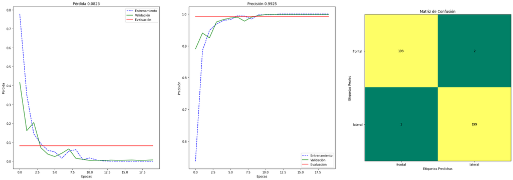

```python
dibujar(clasificador_4, historial_4, evaluacion_4)
```

No ha habido mejora, y ya es suficientemente bueno, de momento usaremos el modelo clasificador_3 para el proyecto.

## 1.5. Modelo 5

El último modelo voy a usar mse como pérdida, para ver si mejora el rendimiento al usar una función de regresión.

```python
entrada = tf.keras.Input(shape=(IMG_LADO, IMG_LADO, 1))

# Extraer caracteristicas
# 128
x = tf.keras.layers.Conv2D(16, (3, 3), activation='relu', padding='same')(entrada)
x = tf.keras.layers.Conv2D(16, (3, 3), activation='relu', padding='same')(x)
x = tf.keras.layers.MaxPooling2D(pool_size=(2, 2))(x)

# 64
x = tf.keras.layers.Conv2D(32, (3, 3), activation='relu', padding='same')(x)
x = tf.keras.layers.Conv2D(32, (3, 3), activation='relu', padding='same')(x)
x = tf.keras.layers.MaxPooling2D(pool_size=(2, 2))(x)

# 32
x = tf.keras.layers.Conv2D(64, (3, 3), activation='relu', padding='same')(x)
x = tf.keras.layers.Conv2D(64, (3, 3), activation='relu', padding='same')(x)
x = tf.keras.layers.MaxPooling2D(pool_size=(2, 2))(x)

# 16
x = tf.keras.layers.Conv2D(128, (3, 3), activation='relu', padding='same')(x)
x = tf.keras.layers.Conv2D(128, (3, 3), activation='relu', padding='same')(x)
x = tf.keras.layers.MaxPooling2D(pool_size=(2, 2))(x)

# Claisificador
x = tf.keras.layers.Flatten()(x)
x = tf.keras.layers.Dense(128, activation='relu')(x)
x = tf.keras.layers.Dense(64, activation='relu')(x)
x = tf.keras.layers.Dense(32, activation='relu')(x)
x = tf.keras.layers.Dense(16, activation='relu')(x)
x = tf.keras.layers.Dense(1, activation='sigmoid')(x)

clasificador_5 = tf.keras.Model(inputs=entrada, outputs=x)
clasificador_5.compile(optimizer = 'rmsprop', loss = 'mse', metrics = ['binary_accuracy'])
```

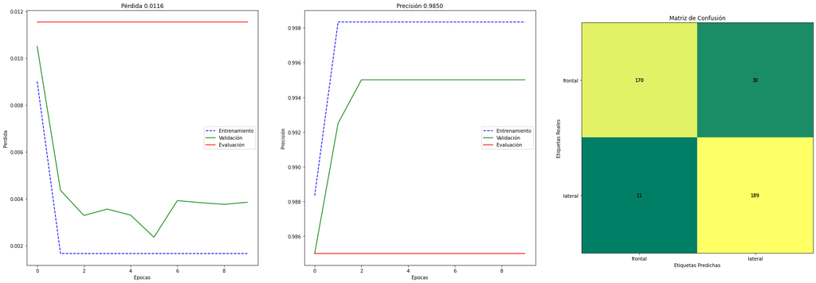

```python
entrenar_y_visualizar(clasificador_5, 'clasificador_5')
```

Con la pérdida mse, el 10.25% de los registros son erróneos.

# 2. Selección de modelo.

El rendimiento de los modelos ha sido el siguiente:

| modelo | optimizador | perdida | % error |
| --- | --- | --- | --- |
| 3 | rmsprop | binary_crossentropy | 0.75 |
| 4 | rmsprop (ajuste fino) | binary_crossentropy | 0.75 |
| 1 | adam | binary_crossentropy | 2.00 |
| 2 | adam | mse | 3.00 |
| 5 | rmsprop | mse | 10.25 |

El modelo final es el modelo 3, ya que tiene el error más bajo y tras probar a ajustarlo, no ha habido mejora, con lo que es la mejor versión que podemos obtener de esa arquitectura en concreto.

Los modelos entrenados se pueden descargar en [Github](https://github.com/hechix/Clasificar-y-segmentar-radiografias)